# Modeling and prediction for movies

## Setup

### Load packages

```r
library(ggplot2)
library(dplyr)
library(statsr)
library(GGally)
library(corrplot)
```

### Load data

```r
time <- proc.time()
load("_e1fe0c85abec6f73c72d73926884eaca_movies.Rdata")
MovieData <- movies
```

## Part 1: Data

The data collected is random and consists of *651 rows* [651 Movies] and *32 columns* representing various properties. This data is collected from [IMDB](http://www.imdb.com) and [Rotten Tomatoes](https://www.rottentomatoes.com).

*The Internet Movie Database (abbreviated IMDb)* is an online database of information related to films, television programs and video games, including cast, production crew, fictional characters, biographies, plot summaries, trivia and reviews.

*Rotten Tomatoes* is a website launched in August 1998 devoted to film reviews, news and details; it is widely known as a film review aggregator. Coverage now includes TV content as well. The name derives from the practice of audiences throwing rotten tomatoes when disapproving of a poor stage performance.

The movie data have several categorical and numerical variables & would be a good fit for modeling to predict the Popularity a movie might get.

## Part 2: Research question

We will be using the data from [Rotten Tomatoes](https://www.rottentomatoes.com) to check the predictions from the model.

## Part 3: Exploratory data analysis

```r
# cleaning data
movies<- movies[,-1]
movies<- movies[-30:-31]

#Converting the data set to a numerical data
df1<-as.matrix(sapply(movies, as.numeric))
df1<- as.data.frame(df1)
df2 <- df1
df2 <- df2[-24:-29]
df2 <- df2[-9:-11]
df2 <- df2[-5]
df2 <- df2[-3]
# finding the correlation between various features.
cor(df2)
```

```
##                    title_type       genre  mpaa_rating thtr_rel_year
## title_type        1.000000000  0.06154262 -0.147172326 -0.1292066170
## genre             0.061542620  1.00000000  0.190203873 -0.0598869699
## mpaa_rating      -0.147172326  0.19020387  1.000000000  0.2630539593
## thtr_rel_year    -0.129206617 -0.05988697  0.263053959  1.0000000000
## thtr_rel_month    0.008865031 -0.02787292 -0.002083033 -0.0005074123
## thtr_rel_day      0.024698061 -0.01677116 -0.029500932  0.1074002137
## imdb_rating      -0.323016420  0.14727044  0.139756764 -0.0300030887
## imdb_num_votes    0.122410407  0.04884518  0.001969696  0.1559058800
## critics_rating    0.215839950 -0.12502732 -0.107896408 -0.0489897655
## critics_score    -0.311902661  0.16972967  0.109121186 -0.0807848132
## audience_rating  -0.244810954  0.05010350  0.089885153 -0.0436874564
## audience_score   -0.304595297  0.06958859  0.087319648 -0.0540788099
## best_pic_nom      0.048904962  0.08379846 -0.019656290 -0.0470667556
## best_pic_win      0.027262959  0.02791027 -0.009679122 -0.0496976776
## best_actor_win    0.076864142  0.09299524 -0.048561057 -0.0594738116
## best_actress_win  0.092213366  0.09816436 -0.026131004 -0.0374259822
## best_dir_win      0.069542348  0.05971453  0.002843958 -0.1074323924
## top200_box        0.040159101 -0.03751922 -0.142709837 -0.0692047958
##                  thtr_rel_month thtr_rel_day imdb_rating imdb_num_votes
## title_type         0.0088650314  0.024698061 -0.32301642    0.122410407
## genre             -0.0278729231 -0.016771160  0.14727044    0.048845184
## mpaa_rating       -0.0020830327 -0.029500932  0.13975676    0.001969696
## thtr_rel_year     -0.0005074123  0.107400214 -0.03000309    0.155905880
## thtr_rel_month     1.0000000000  0.116227698  0.07227836    0.106325862
## thtr_rel_day       0.1162276975  1.000000000  0.02189115    0.067976026
## imdb_rating        0.0722783644  0.021891153  1.00000000    0.331152477
## imdb_num_votes     0.1063258618  0.067976026  0.33115248    1.000000000
## critics_rating    -0.0456355217 -0.062149580 -0.61774771   -0.338814752
## critics_score      0.0324043199  0.013689388  0.76503550    0.209250812
## audience_rating    0.0355598573  0.028265606  0.69517958    0.225270425
## audience_score     0.0326903088  0.019220523  0.86486516    0.289812788
## best_pic_nom       0.1692546947  0.020009722  0.21686854    0.327624391
## best_pic_win       0.0621388787  0.035468724  0.13532520    0.318143308
## best_actor_win     0.0928791489  0.022451508  0.06456737    0.083189876
## best_actress_win   0.0547366583  0.053117013  0.07138282    0.121787393
## best_dir_win       0.0803887861 -0.005518136  0.13464202    0.190563615
## top200_box         0.0832957257  0.006655358  0.09165752    0.291063833
##                  critics_rating critics_score audience_rating
## title_type           0.21583995   -0.31190266     -0.24481095
```

[output cut: 40 more lines]

```
## thtr_rel_year         -0.03742598 -0.107432392 -0.069204796
## thtr_rel_month         0.05473666  0.080388786  0.083295726
## thtr_rel_day           0.05311701 -0.005518136  0.006655358
## imdb_rating            0.07138282  0.134642018  0.091657517
## imdb_num_votes         0.12178739  0.190563615  0.291063833
## critics_rating        -0.06917260 -0.129646732 -0.143813189
## critics_score          0.06082246  0.134759549  0.096562298
## audience_rating        0.02394345  0.052141465  0.089882764
## audience_score         0.02639448  0.094087221  0.092498141
## best_pic_nom           0.20509365  0.155621297  0.084597088
## best_pic_win           0.15318696  0.332068208  0.083258101
## best_actor_win         0.13596520  0.103519512  0.054336735
## best_actress_win       1.00000000  0.083693039  0.076419686
## best_dir_win           0.08369304  1.000000000  0.041601134
## top200_box             0.07641969  0.041601134  1.000000000
```

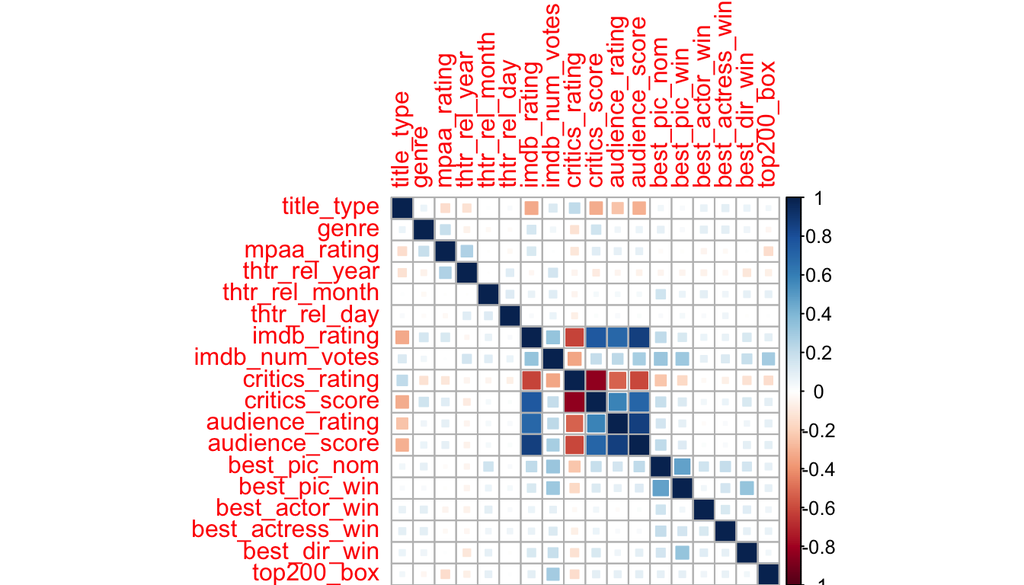

```r
corrplot(cor(df2), "square")
```

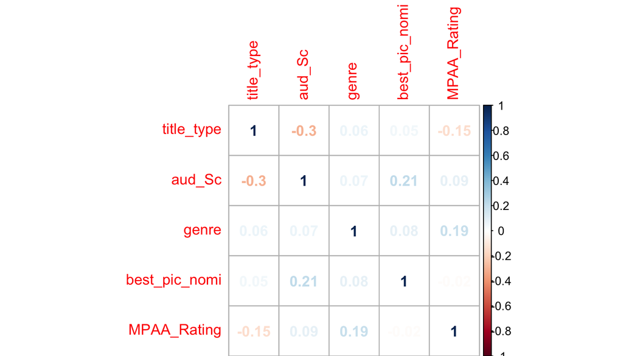

```r
##### Correlation of Audience Score with various features
test1<- as.data.frame(as.numeric(movies$title_type))
names(test1) <- "title_type"
test1$aud_Sc  <- as.numeric(movies$audience_score)
test1$genre<- as.numeric(movies$genre)
test1$best_pic_nomi  <- as.numeric(movies$best_pic_nom)
test1$MPAA_Rating<-as.numeric(movies$mpaa_rating)
corrplot(cor(test1),"number")
```

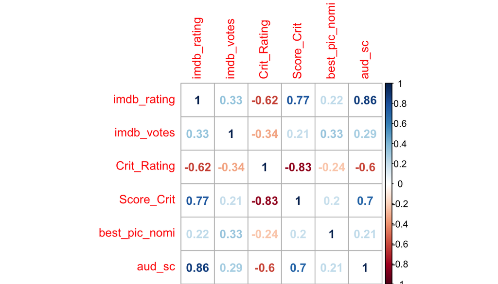

```r
### Second Round for Correlation of Audience Score for remaining features
test2 <- as.data.frame(as.numeric(movies$imdb_rating))
names(test2) <- "imdb_rating"
test2$imdb_votes  <- as.numeric(movies$imdb_num_votes)
test2$Crit_Rating <- as.numeric(movies$critics_rating)
test2$Score_Crit <- as.numeric(movies$critics_score)
test2$best_pic_nomi <- as.numeric(movies$best_pic_nom)
test2$aud_sc <-test1$aud_Sc  <- as.numeric(movies$audience_score)
corrplot(cor(test2),"number")
```

*So Far* we are able to understand the corelation between various features in the dataset. Now we have a clear image of which features would introduce colinearity in the model. So, we can just select features with forwards selection approach and check the adjusted R^2 value and finally work with the significant p-value to get the best model.

## Part 4: Modeling

```r
# Job starts here
MovieDF<- df1
# function to extract R-square for different predictors
model_step1<-function(x) {
  m<-lm(MovieDF$audience_score ~ x)
  summary(m)$adj.r.squared
}

model1.1 <- model_step1(MovieDF$runtime)
model1.2 <- model_step1(MovieDF$thtr_rel_year)
model1.3 <- model_step1(MovieDF$thtr_rel_month)
model1.4 <- model_step1(MovieDF$thtr_rel_day)
model1.5 <- model_step1(MovieDF$critics_score)
model1.6 <- model_step1(MovieDF$best_pic_win)
model1.7 <- model_step1(MovieDF$best_actor_win)
model1.8 <- model_step1(MovieDF$best_actress_win)
model1.9 <- model_step1(MovieDF$best_dir_win)
model1.10 <- model_step1(MovieDF$top200_box)
model1.11 <- model_step1(MovieDF$genre)
model1.12 <- model_step1(MovieDF$mpaa_rating)

M1Value<- c(model1.1,model1.2,model1.3,model1.4,model1.5,model1.6,model1.7,model1.8,model1.9,model1.10,model1.11,model1.12)

cat("Max Adj. R^2 value obtained in this step:",max(M1Value),"for Model1.5 for 'critics_score'")
```

```
## Max Adj. R^2 value obtained in this step: 0.4952284 for Model1.5 for 'critics_score'
```

```r
model_step2<-function(x) {
  m<-lm(MovieDF$audience_score ~ movies$critics_score + x)
  summary(m)$adj.r.squared
}

model2.1 <- model_step2(MovieDF$runtime)
model2.2 <- model_step2(MovieDF$thtr_rel_year)
model2.3 <- model_step2(MovieDF$thtr_rel_month)
model2.4 <- model_step2(MovieDF$thtr_rel_day)
model2.5 <- model_step2(MovieDF$best_pic_win)
model2.6 <- model_step2(MovieDF$best_actor_win)
model2.7 <- model_step2(MovieDF$best_actress_win)
model2.8 <- model_step2(MovieDF$best_dir_win)
model2.9 <- model_step2(MovieDF$top200_box)
model2.10 <- model_step2(MovieDF$genre)
model2.11 <- model_step2(MovieDF$mpaa_rating)

M1Value<- c(model2.1,model2.2,model2.3,model2.4,model2.5,model2.6,model2.7,model2.8,model2.9,model2.10,model2.11)

max(M1Value)
```

```
## [1] 0.4979388
```

```r
cat("Max Adj. R^2 value obtained in this step:",max(M1Value),"for Model1.5 for 'runtime'")
```

```
## Max Adj. R^2 value obtained in this step: 0.4979388 for Model1.5 for 'runtime'
```

```r
model_step3<-function(x) {
  m<-lm(MovieDF$audience_score ~ movies$critics_score + movies$runtime + x)
summary(m)$adj.r.squared
}

model3.1 <- model_step3(MovieDF$thtr_rel_year)
model3.2 <- model_step3(MovieDF$thtr_rel_month)
model3.3 <- model_step3(MovieDF$thtr_rel_day)
model3.4 <- model_step3(MovieDF$best_pic_win)
model3.5 <- model_step3(MovieDF$best_actor_win)
model3.6 <- model_step3(MovieDF$best_actress_win)
model3.7 <- model_step3(MovieDF$best_dir_win)
model3.8 <- model_step3(MovieDF$top200_box)
model3.9 <- model_step3(MovieDF$genre)
model3.10 <- model_step3(MovieDF$mpaa_rating)

M1Value<- c(model3.1,model3.2,model3.3,model3.4,model3.5,model3.6,model3.7,model3.8,model3.9,model3.10)

max(M1Value)
```

```
## [1] 0.5006364
```

```r
cat("Max Adj. R^2 value obtained in this step:",max(M1Value),"for Model1.5 for 'best_actor_win'")
```

```
## Max Adj. R^2 value obtained in this step: 0.5006364 for Model1.5 for 'best_actor_win'
```

```r
model_step4<-function(x) {
  m<-lm(MovieDF$audience_score ~ movies$critics_score + movies$runtime + movies$best_actor_win + x)
summary(m)$adj.r.squared
}

model4.1 <- model_step4(MovieDF$thtr_rel_year)
model4.2 <- model_step4(MovieDF$thtr_rel_month)
model4.3 <- model_step4(MovieDF$thtr_rel_day)
model4.4 <- model_step4(MovieDF$best_pic_win)
model4.5 <- model_step4(MovieDF$best_actress_win)
model4.6 <- model_step4(MovieDF$best_dir_win)
model4.7 <- model_step4(MovieDF$top200_box)
model4.8 <- model_step4(MovieDF$genre)
model4.9 <- model_step4(MovieDF$mpaa_rating)

M1Value<- c(model4.1,model4.2,model4.3,model4.4,model4.5,model4.6,model4.7,model4.8,model4.9)

max(M1Value)
```

```
## [1] 0.5006367
```

```r
cat("Max Adj. R^2 value obtained in this step:",max(M1Value),"for Model1.5 for 'genre'")
```

```
## Max Adj. R^2 value obtained in this step: 0.5006367 for Model1.5 for 'genre'
```

```r
Final_Model<-lm(audience_score ~ critics_score + genre +runtime + best_actor_win, data = MovieDF)
summary(Final_Model)
```

```
##
## Call:
## lm(formula = audience_score ~ critics_score + genre + runtime +
##     best_actor_win, data = MovieDF)
##
## Residuals:
##     Min      1Q  Median      3Q     Max
## -40.224  -9.984   0.212  10.075  42.341
##
## Coefficients:
##                Estimate Std. Error t value Pr(>|t|)
## (Intercept)    29.95147    3.43502   8.719  < 2e-16 ***
## critics_score   0.50018    0.02028  24.664  < 2e-16 ***
## genre          -0.53015    0.25724  -2.061  0.03972 *
## runtime         0.07939    0.03052   2.601  0.00952 **
## best_actor_win -1.66350    1.66317  -1.000  0.31759
## ---
## Signif. codes:  0 '***' 0.001 '**' 0.01 '*' 0.05 '.' 0.1 ' ' 1
##
## Residual standard error: 14.3 on 645 degrees of freedom
##   (1 observation deleted due to missingness)
## Multiple R-squared:  0.5037, Adjusted R-squared:  0.5006
## F-statistic: 163.7 on 4 and 645 DF,  p-value: < 2.2e-16
```

*Ploting the Model with 4 features*

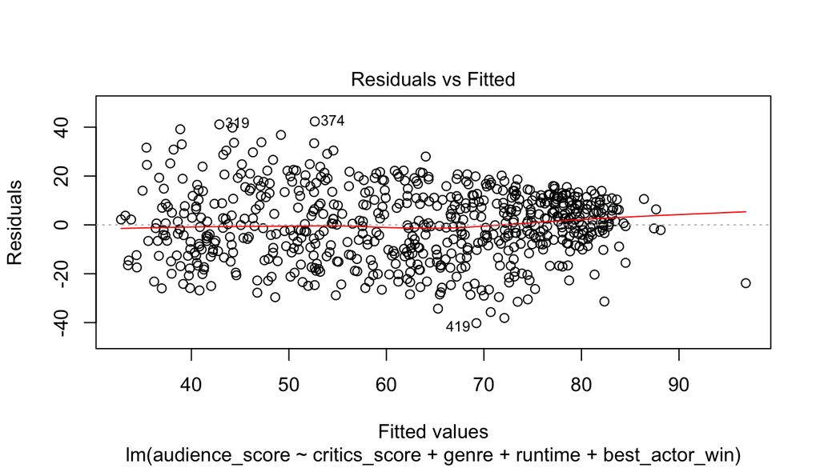

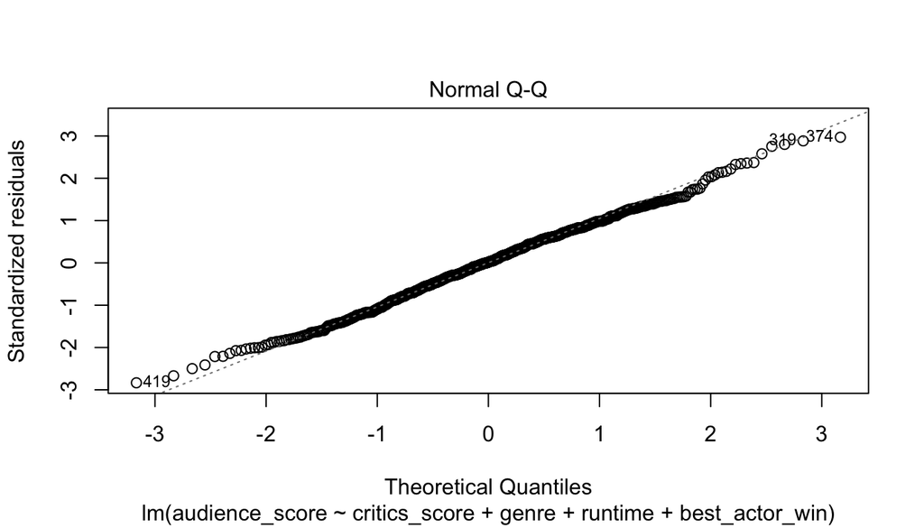

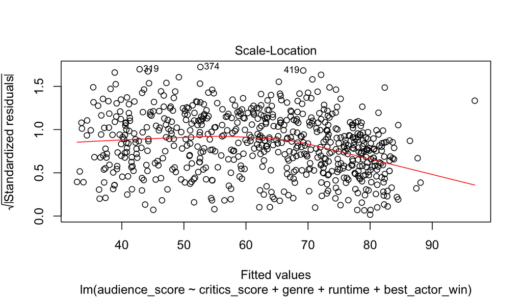

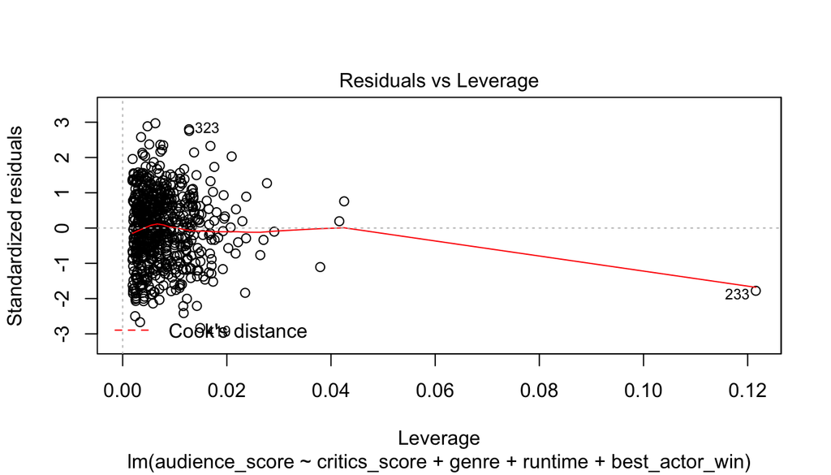

```r
plot(Final_Model)
```

*Interpretation of the equation:* PredictedAudienceScore = 29.95147 + (0.50018 * critics_score)- (0.53015 * genre) + (0.07939 * runtime) - (1.66350 * best_actor_win)

*Intercept:*

- A movie with no critics score, and is 0 minutes long, and does not have a Best Actor Win will have a predicted Audience Score of 29.95147 which is almost 30.

*Slope:*

- All else held constant, for each unit increase critics score, the model predicts that the audience score will increase on average by 0.50018
- All else held constant, for a Genre type, the model predicts that the audience score will decrease by 0.53015 on an average
- All else held constant, for each unit increase runtime, the model predicts that the audience score will increase on average by 0.07939
- All else held constant, for a Best Actor Win, the model predicts that the audience score will decrease by 1.66350 on an average

## Part 5: Prediction

```r
levels(factor(MovieData$genre))
```

```
##  [1] "Action & Adventure"        "Animation"
##  [3] "Art House & International" "Comedy"
##  [5] "Documentary"               "Drama"
##  [7] "Horror"                    "Musical & Performing Arts"
##  [9] "Mystery & Suspense"        "Other"
## [11] "Science Fiction & Fantasy"
```

```r
# test data set from website for arrival movie
Movie2016 <- data.frame(critics_score = 93, runtime = 118, best_actor_win = 0, genre = 6)
pred<-predict(Final_Model, Movie2016, interval = "prediction", level = 0.95)
cat("Audience Score for Arrival Movie:",pred[1],"and CI Lower:", pred[2],"CI Upper:",pred[3],"\n")
```

```
## Audience Score for Arrival Movie: 82.65474 and CI Lower: 54.24606 CI Upper: 111.0634
```

```r
# test data set from website for "Inferno" movie
Movie2016 <- data.frame(critics_score = 21, runtime = 121, best_actor_win = 0, genre = 9)
pred<-predict(Final_Model, Movie2016, interval = "prediction", level = 0.95)
cat("Audience Score for Inferno Movie:",pred[1],"and CI Lower:", pred[2],"CI Upper:",pred[3],"\n")
```

```
## Audience Score for Inferno Movie: 45.28971 and CI Lower: 16.77902 CI Upper: 73.8004
```

```r
# test data set from website for "Shut In"" movie
Movie2016 <- data.frame(critics_score = 0, runtime = 91, best_actor_win = 0,genre =9)
pred<-predict(Final_Model, Movie2016, interval = "prediction", level = 0.95)
cat("Audience Score for Shut In Movie: ",pred[1],"and CI Lower:", pred[2],"CI Upper:",pred[3],"\n")
```

```
## Audience Score for Shut In Movie:  32.40437 and CI Lower: 3.895847 CI Upper: 60.9129
```

The *Movies* used for the prediction with their actual Audience Score can be found by clicking on the link below:

[Arrival](https://www.rottentomatoes.com/m/arrival_2016) : *Audience Score 83*

[Inferno](https://www.rottentomatoes.com/m/inferno_2016) : *Audience Score 43*

[Shut In](https://www.rottentomatoes.com/m/shut_in) : *Audience Score 27*

## Part 6: Conclusion

The Multivariate Linear Regression Model is able to predict with a variance of 50.06% as adjusted *R^2* value, which means that this model can explain upto 50.06% and leaving 49.94% uncovered. The audience score predicted by model is pretty accurate for the data given for training and with the given features. If we can have more features the model can perform better.